# NLP Project Report

Najada Feimi, Elnaz Khaveh, Hamed Vaheb

12/29/2022

# 1 **Import Libraries**

```r
library(rmarkdown)
library(dplyr)
library(ggplot2)
library(broom)
library(janitor)
library(renv)
library(purrr)
library(tm)
library(SnowballC)
library(RColorBrewer)
library(ggplot2)
library(wordcloud)
library(biclust)
library(cluster)
library(igraph)
library(fpc)
library(magrittr)
library(rmarkdown)
library(textreuse)
library(slam)

#packages <- c("tm", "SnowballCC", "RColorBrewer", "ggplot2", "wordcloud", "biclust", "cluster", "igraph", "fpc", "knitr", "dplyr", "broom", "janitor", "renv", "purrr")
#install.packages(packages, dependencies = TRUE)
```

# 2 **Introduction**

## 2.1 **Describe Dataset**

The dataset used for this project is president speeches obtained from [this link](https://www.presidency.ucsb.edu/documents/presidential-documents-archive-guidebook/inaugural-addresses).

Using the following script in Python, we first created a dataframe of the website’s speeches:

```
import requests
from bs4 import BeautifulSoup
import pandas as pd

# Scrapes transcripts for inaugural addresses


def get_urls(url):
    '''Returns list of transcript urls'''

    page = requests.get(url).text
    soup=BeautifulSoup(page, 'lxml')
    url_table = soup.find("table", class_='table').find_all("a")
    return [u["href"] for u in url_table]

urls = get_urls("https://www.presidency.ucsb.edu/documents/presidential-documents-archive-guidebook/inaugural-addresses")

transcripts = pd.DataFrame()

def get_transcripts(urls, transcripts):
    for u in urls:
        page = requests.get(u).text
        soup = BeautifulSoup(page, 'lxml')
        t_president = soup.find("h3", class_="diet-title").text
        t_year = soup.find("span", class_="date-display-single").text.split(',')[1].strip()
        t_content = soup.find("div", class_="field-docs-content").text
        record = {
            'president' : t_president,
            'year' : t_year,
            'content' : t_content
        }
        transcripts = transcripts.append(record, ignore_index=True)
    return transcripts

data = get_transcripts(urls,transcripts)
data.to_csv("us_presidents_transcripts.csv", sep="|")
```

In what follows, we load the dataframe:

```r
df <- read.csv("https://raw.githubusercontent.com/berserkhmdvhb/MADS-NLP/main/data/presidents-speech.csv")
```

```r
df |> dplyr::glimpse()
```

```
## Rows: 59
## Columns: 4
## $ X         <int> 0, 1, 2, 3, 4, 5, 6, 7, 8, 9, 10, 11, 12, 13, 14, 15, 16, 17…
## $ president <chr> "George Washington", "George Washington", "John Adams", "Tho…
## $ year      <int> 1789, 1793, 1797, 1801, 1805, 1809, 1813, 1817, 1821, 1825, …
## $ content   <chr> "\nFellow-Citizens of the Senate and of the House of Represe…
```

```r
df |> summary()
```

```
##        X         president              year        content
##  Min.   : 0.0   Length:59          Min.   :1789   Length:59
##  1st Qu.:14.5   Class :character   1st Qu.:1847   Class :character
##  Median :29.0   Mode  :character   Median :1905   Mode  :character
##  Mean   :29.0                      Mean   :1905
##  3rd Qu.:43.5                      3rd Qu.:1963
##  Max.   :58.0                      Max.   :2021
```

In what follows, text files are generated from each row of dataframe and are stored in “texts” folder:

```r
#presidents <- df[["president"]]|> unique() |>as.list()

for(i in 1:nrow(df)) {       # for-loop over rows
  df_i <- df[i, ]
  name <- df_i$president
  year <- df_i$year
  text <- df_i$content
  file_name <- paste(as.character(year),
                     as.character(name),
                     sep="-")
  file_name <- paste(file_name, ".txt",
                     sep="")
  loc <- paste("./data/texts/", file_name, sep="")
  #writeLines(text, loc)
}
```

```r
loc <- "./data/texts/"
docs <- tm::VCorpus(DirSource(loc))
summary(docs)
```

```
##                                 Length Class             Mode
## 1789-George Washington.txt      2      PlainTextDocument list
## 1793-George Washington.txt      2      PlainTextDocument list
## 1797-John Adams.txt             2      PlainTextDocument list
## 1801-Thomas Jefferson.txt       2      PlainTextDocument list
## 1805-Thomas Jefferson.txt       2      PlainTextDocument list
## 1809-James Madison.txt          2      PlainTextDocument list
## 1813-James Madison.txt          2      PlainTextDocument list
## 1817-James Monroe.txt           2      PlainTextDocument list
## 1821-James Monroe.txt           2      PlainTextDocument list
## 1825-John Quincy Adams.txt      2      PlainTextDocument list
## 1829-Andrew Jackson.txt         2      PlainTextDocument list
## 1833-Andrew Jackson.txt         2      PlainTextDocument list
## 1837-Martin van Buren.txt       2      PlainTextDocument list
## 1841-William Henry Harrison.txt 2      PlainTextDocument list
## 1845-James K. Polk.txt          2      PlainTextDocument list
## 1849-Zachary Taylor.txt         2      PlainTextDocument list
## 1853-Franklin Pierce.txt        2      PlainTextDocument list
## 1857-James Buchanan.txt         2      PlainTextDocument list
## 1861-Abraham Lincoln.txt        2      PlainTextDocument list
## 1865-Abraham Lincoln.txt        2      PlainTextDocument list
## 1869-Ulysses S. Grant.txt       2      PlainTextDocument list
## 1873-Ulysses S. Grant.txt       2      PlainTextDocument list
## 1877-Rutherford B. Hayes.txt    2      PlainTextDocument list
## 1881-James A. Garfield.txt      2      PlainTextDocument list
## 1885-Grover Cleveland.txt       2      PlainTextDocument list
## 1889-Benjamin Harrison.txt      2      PlainTextDocument list
## 1893-Grover Cleveland.txt       2      PlainTextDocument list
## 1897-William McKinley.txt       2      PlainTextDocument list
## 1901-William McKinley.txt       2      PlainTextDocument list
## 1905-Theodore Roosevelt.txt     2      PlainTextDocument list
## 1909-William Howard Taft.txt    2      PlainTextDocument list
## 1913-Woodrow Wilson.txt         2      PlainTextDocument list
## 1917-Woodrow Wilson.txt         2      PlainTextDocument list
## 1921-Warren G. Harding.txt      2      PlainTextDocument list
## 1925-Calvin Coolidge.txt        2      PlainTextDocument list
## 1929-Herbert Hoover.txt         2      PlainTextDocument list
## 1933-Franklin D. Roosevelt.txt  2      PlainTextDocument list
## 1937-Franklin D. Roosevelt.txt  2      PlainTextDocument list
## 1941-Franklin D. Roosevelt.txt  2      PlainTextDocument list
## 1945-Franklin D. Roosevelt.txt  2      PlainTextDocument list
## 1949-Harry S. Truman.txt        2      PlainTextDocument list
## 1953-Dwight D. Eisenhower.txt   2      PlainTextDocument list
## 1957-Dwight D. Eisenhower.txt   2      PlainTextDocument list
## 1961-John F. Kennedy.txt        2      PlainTextDocument list
## 1965-Lyndon B. Johnson.txt      2      PlainTextDocument list
## 1969-Richard Nixon.txt          2      PlainTextDocument list
## 1973-Richard Nixon.txt          2      PlainTextDocument list
## 1977-Jimmy Carter.txt           2      PlainTextDocument list
## 1981-Ronald Reagan.txt          2      PlainTextDocument list
## 1985-Ronald Reagan.txt          2      PlainTextDocument list
## 1989-George Bush.txt            2      PlainTextDocument list
## 1993-William J. Clinton.txt     2      PlainTextDocument list
## 1997-William J. Clinton.txt     2      PlainTextDocument list
## 2001-George W. Bush.txt         2      PlainTextDocument list
## 2005-George W. Bush.txt         2      PlainTextDocument list
## 2009-Barack Obama.txt           2      PlainTextDocument list
## 2013-Barack Obama.txt           2      PlainTextDocument list
## 2017-Donald J. Trump.txt        2      PlainTextDocument list
## 2021-Joseph R. Biden.txt        2      PlainTextDocument list
```

```r
inspect(docs[1])
```

```
## <<VCorpus>>
## Metadata:  corpus specific: 0, document level (indexed): 0
## Content:  documents: 1
##
## [[1]]
## <<PlainTextDocument>>
## Metadata:  7
## Content:  chars: 8617
```

```r
writeLines(as.character(docs[1]))
```

```
## list(list(content = c("", "Fellow-Citizens of the Senate and of the House of Representatives:", "Among the vicissitudes incident to life no event could have filled me with greater anxieties than that of which the notification was transmitted by your order, and received on the 14th day of the pres…
## "Such being the impressions under which I have, in obedience to the public summons, repaired to the present station, it would be peculiarly improper to omit in this first official act my fervent supplications to that Almighty Being who rules over the universe, who presides in the councils of nati…
## "By the article establishing the executive department it is made the duty of the President \"to recommend to your consideration such measures as he shall judge necessary and expedient.\" The circumstances under which I now meet you will acquit me from entering into that subject further than to re…
## "Besides the ordinary objects submitted to your care, it will remain with your judgment to decide how far an exercise of the occasional power delegated by the fifth article of the Constitution is rendered expedient at the present juncture by the nature of objections which have been urged against …
## "To the foregoing observations I have one to add, which will be most properly addressed to the House of Representatives. It concerns myself, and will therefore be as brief as possible. When I was first honored with a call into the service of my country, then on the eve of an arduous struggle for …
## "Having thus imparted to you my sentiments as they have been awakened by the occasion which brings us together, I shall take my present leave; but not without resorting once more to the benign Parent of the Human Race in humble supplication that, since He has been pleased to favor the American pe…
## ""), meta = list(author = character(0), datetimestamp = list(sec = 42.2394471168518, min = 56, hour = 14, mday = 2, mon = 0, year = 123, wday = 1, yday = 1, isdst = 0), description = character(0), heading = character(0), id = "1789-George Washington.txt", language = "en", origin = character(0))))
## list()
## list()
```

## 2.2 **Goal and Procedure**

This project is dedicated to investigating text similarity between speeches from different presidents of US during various years, starting from 1789 and ending with 2021.

In Preprocessing section, numerous text mining tasks are implemented on all the docs.

In Word Frequency section, frequency of different terms in documents are analyzed and visualized.

In Conclusion, main findings are summarized.

The github repository for this package can be found in this [link](https://github.com/berserkhmdvhb/MADS-NLP)

# 3 **Preprocessing**

The tm is a framework for text mining applications within R. Most functions used henceforth stems from this package.

## 3.1 **Remove punctuation**

```r
docs <- tm::tm_map(docs,removePunctuation)
writeLines(as.character(docs[1]))
```

```
## list(list(content = c("", "FellowCitizens of the Senate and of the House of Representatives", "Among the vicissitudes incident to life no event could have filled me with greater anxieties than that of which the notification was transmitted by your order and received on the 14th day of the present…
## "Such being the impressions under which I have in obedience to the public summons repaired to the present station it would be peculiarly improper to omit in this first official act my fervent supplications to that Almighty Being who rules over the universe who presides in the councils of nations …
## "By the article establishing the executive department it is made the duty of the President to recommend to your consideration such measures as he shall judge necessary and expedient The circumstances under which I now meet you will acquit me from entering into that subject further than to refer t…
## "Besides the ordinary objects submitted to your care it will remain with your judgment to decide how far an exercise of the occasional power delegated by the fifth article of the Constitution is rendered expedient at the present juncture by the nature of objections which have been urged against t…
## "To the foregoing observations I have one to add which will be most properly addressed to the House of Representatives It concerns myself and will therefore be as brief as possible When I was first honored with a call into the service of my country then on the eve of an arduous struggle for its l…
## "Having thus imparted to you my sentiments as they have been awakened by the occasion which brings us together I shall take my present leave but not without resorting once more to the benign Parent of the Human Race in humble supplication that since He has been pleased to favor the American peopl…
## ""), meta = list(author = character(0), datetimestamp = list(sec = 42.2394471168518, min = 56, hour = 14, mday = 2, mon = 0, year = 123, wday = 1, yday = 1, isdst = 0), description = character(0), heading = character(0), id = "1789-George Washington.txt", language = "en", origin = character(0))))
## list()
## list()
```

## 3.2 **Remove special characters**

```r
for (j in seq(docs)) {
    docs[[j]] <- gsub("/", " ", docs[[j]])
    docs[[j]] <- gsub("@", " ", docs[[j]])
    docs[[j]] <- gsub("\\|", " ", docs[[j]])
    docs[[j]] <- gsub("\u2028", " ", docs[[j]])  # This is an ascii character that did not translate, so it had to be removed.
}
writeLines(as.character(docs[1]))
```

```
## list(c("", "FellowCitizens of the Senate and of the House of Representatives", "Among the vicissitudes incident to life no event could have filled me with greater anxieties than that of which the notification was transmitted by your order and received on the 14th day of the present month On the o…
## "Such being the impressions under which I have in obedience to the public summons repaired to the present station it would be peculiarly improper to omit in this first official act my fervent supplications to that Almighty Being who rules over the universe who presides in the councils of nations …
## "By the article establishing the executive department it is made the duty of the President to recommend to your consideration such measures as he shall judge necessary and expedient The circumstances under which I now meet you will acquit me from entering into that subject further than to refer t…
## "Besides the ordinary objects submitted to your care it will remain with your judgment to decide how far an exercise of the occasional power delegated by the fifth article of the Constitution is rendered expedient at the present juncture by the nature of objections which have been urged against t…
## "To the foregoing observations I have one to add which will be most properly addressed to the House of Representatives It concerns myself and will therefore be as brief as possible When I was first honored with a call into the service of my country then on the eve of an arduous struggle for its l…
## "Having thus imparted to you my sentiments as they have been awakened by the occasion which brings us together I shall take my present leave but not without resorting once more to the benign Parent of the Human Race in humble supplication that since He has been pleased to favor the American peopl…
## ""))
## list()
## list()
```

## 3.3 **Remove numbers**

```r
docs <- tm::tm_map(docs, removeNumbers)
writeLines(as.character(docs[1]))
```

```
## list(c("", "FellowCitizens of the Senate and of the House of Representatives", "Among the vicissitudes incident to life no event could have filled me with greater anxieties than that of which the notification was transmitted by your order and received on the th day of the present month On the one…
## "Such being the impressions under which I have in obedience to the public summons repaired to the present station it would be peculiarly improper to omit in this first official act my fervent supplications to that Almighty Being who rules over the universe who presides in the councils of nations …
## "By the article establishing the executive department it is made the duty of the President to recommend to your consideration such measures as he shall judge necessary and expedient The circumstances under which I now meet you will acquit me from entering into that subject further than to refer t…
## "Besides the ordinary objects submitted to your care it will remain with your judgment to decide how far an exercise of the occasional power delegated by the fifth article of the Constitution is rendered expedient at the present juncture by the nature of objections which have been urged against t…
## "To the foregoing observations I have one to add which will be most properly addressed to the House of Representatives It concerns myself and will therefore be as brief as possible When I was first honored with a call into the service of my country then on the eve of an arduous struggle for its l…
## "Having thus imparted to you my sentiments as they have been awakened by the occasion which brings us together I shall take my present leave but not without resorting once more to the benign Parent of the Human Race in humble supplication that since He has been pleased to favor the American peopl…
## ""))
## list()
## list()
```

## 3.4 **Convert to lowercase**

```r
docs <- tm::tm_map(docs, tolower)
docs <- tm::tm_map(docs, PlainTextDocument)
DocsCopy <- docs
writeLines(as.character(docs[1]))
```

```
## list(list(content = c("", "fellowcitizens of the senate and of the house of representatives", "among the vicissitudes incident to life no event could have filled me with greater anxieties than that of which the notification was transmitted by your order and received on the th day of the present m…
## "such being the impressions under which i have in obedience to the public summons repaired to the present station it would be peculiarly improper to omit in this first official act my fervent supplications to that almighty being who rules over the universe who presides in the councils of nations …
## "by the article establishing the executive department it is made the duty of the president to recommend to your consideration such measures as he shall judge necessary and expedient the circumstances under which i now meet you will acquit me from entering into that subject further than to refer t…
## "besides the ordinary objects submitted to your care it will remain with your judgment to decide how far an exercise of the occasional power delegated by the fifth article of the constitution is rendered expedient at the present juncture by the nature of objections which have been urged against t…
## "to the foregoing observations i have one to add which will be most properly addressed to the house of representatives it concerns myself and will therefore be as brief as possible when i was first honored with a call into the service of my country then on the eve of an arduous struggle for its l…
## "having thus imparted to you my sentiments as they have been awakened by the occasion which brings us together i shall take my present leave but not without resorting once more to the benign parent of the human race in humble supplication that since he has been pleased to favor the american peopl…
## ""), meta = list(author = character(0), datetimestamp = list(sec = 42.4707429409027, min = 56, hour = 14, mday = 2, mon = 0, year = 123, wday = 1, yday = 1, isdst = 0), description = character(0), heading = character(0), id = character(0), language = character(0), origin = character(0))))
## list()
## list()
```

## 3.5 **Remove “stopwords”**

```r
# For a list of the stopwords, see:
length(stopwords("english"))
```

```
## [1] 174
```

```r
docs <- tm::tm_map(docs, removeWords, stopwords("english"))
docs <- tm::tm_map(docs, PlainTextDocument)
writeLines(as.character(docs[1]))
```

```
## list(list(content = c("", "fellowcitizens   senate    house  representatives", "among  vicissitudes incident  life  event   filled   greater anxieties      notification  transmitted   order  received   th day   present month   one hand   summoned   country whose voice  can never hear   veneration…
## "   impressions      obedience   public summons repaired   present station    peculiarly improper  omit   first official act  fervent supplications   almighty   rules   universe  presides   councils  nations  whose providential aids can supply every human defect   benediction may consecrate   lib…
## "  article establishing  executive department   made  duty   president  recommend   consideration  measures   shall judge necessary  expedient  circumstances    now meet  will acquit   entering   subject    refer   great constitutional charter     assembled    defining  powers designates  objects…
## "besides  ordinary objects submitted   care  will remain   judgment  decide  far  exercise   occasional power delegated   fifth article   constitution  rendered expedient   present juncture   nature  objections    urged   system    degree  inquietude   given birth   instead  undertaking particula…
## "  foregoing observations   one  add  will   properly addressed   house  representatives  concerns   will therefore   brief  possible    first honored   call   service   country    eve   arduous struggle   liberties  light    contemplated  duty required    renounce every pecuniary compensation   …
## " thus imparted    sentiments     awakened   occasion  brings us together  shall take  present leave   without resorting     benign parent   human race  humble supplication  since    pleased  favor  american people  opportunities  deliberating  perfect tranquillity  dispositions  deciding  unpara…
## ""), meta = list(author = character(0), datetimestamp = list(sec = 42.8104064464569, min = 56, hour = 14, mday = 2, mon = 0, year = 123, wday = 1, yday = 1, isdst = 0), description = character(0), heading = character(0), id = character(0), language = character(0), origin = character(0))))
## list()
## list()
```

## 3.6 **Remove particular stopwords**

```r
#docs <- tm::tm_map(docs, removeWords, c("syllogism", "tautology"))
# Just remove the words "syllogism" and "tautology".
# These words don't actually exist in these texts. But this is how you would remove them if they had.
```

## 3.7 **Retain compouned words**

If you wish to preserve a concept is only apparent as a collection of two or more words, then you can combine them or reduce them to a meaningful acronym before you begin the analysis. Here, I am using examples that are particular to qualitative data analysis.

```r
for (j in seq(docs))
{
  docs[[j]] <- gsub("fake news", "fake_news", docs[[j]])
  docs[[j]] <- gsub("inner city", "inner-city", docs[[j]])
  docs[[j]] <- gsub("politically correct", "politically_correct", docs[[j]])
}
docs <- tm_map(docs, PlainTextDocument)
```

## 3.8 **Remove common word endings**

Common words ending e.g. “ing”, “es”, “s”

```r
## Note: I did not run this section of code for this particular example.
docs_st <- tm_map(docs, stemDocument)
docs_st <- tm_map(docs_st, PlainTextDocument)
writeLines(as.character(docs_st[1])) # Check to see if it worked.
```

```
## list(list(content = c("", "fellowcitizen senat hous repres", "among vicissitud incid life event fill greater anxieti notif transmit order receiv th day present month one hand summon countri whose voic can never hear vener love retreat chosen fondest predilect flatter hope immut decis asylum decli…
## "impress obedi public summon repair present station peculiar improp omit first offici act fervent supplic almighti rule univers presid council nation whose providenti aid can suppli everi human defect benedict may consecr liberti happi peopl unit state govern institut essenti purpos may enabl eve…
## "articl establish execut depart made duti presid recommend consider measur shall judg necessari expedi circumst now meet will acquit enter subject refer great constitut charter assembl defin power design object attent given will consist circumst far congeni feel actuat substitut place recommend p…
## "besid ordinari object submit care will remain judgment decid far exercis occasion power deleg fifth articl constitut render expedi present junctur natur object urg system degre inquietud given birth instead undertak particular recommend subject guid light deriv offici opportun shall give way ent…
## "forego observ one add will proper address hous repres concern will therefor brief possibl first honor call servic countri eve arduous struggl liberti light contempl duti requir renounc everi pecuniari compens resolut instanc depart still impress produc must declin inapplic share person emolu may…
## ""), meta = list(author = character(0), datetimestamp = list(sec = 43.0657916069031, min = 56, hour = 14, mday = 2, mon = 0, year = 123, wday = 1, yday = 1, isdst = 0), description = character(0), heading = character(0), id = character(0), language = character(0), origin = character(0))))
## list()
## list()
```

```r
# docs <- docs_st
```

## 3.9 **Strip unnecesary whitespace**

```r
docs <- tm_map(docs, stripWhitespace)
writeLines(as.character(docs[1]))
```

```
## list(list(content = c("", "fellowcitizens senate house representatives", "among vicissitudes incident life event filled greater anxieties notification transmitted order received th day present month one hand summoned country whose voice can never hear veneration love retreat chosen fondest predil…
## " impressions obedience public summons repaired present station peculiarly improper omit first official act fervent supplications almighty rules universe presides councils nations whose providential aids can supply every human defect benediction may consecrate liberties happiness people united st…
## " article establishing executive department made duty president recommend consideration measures shall judge necessary expedient circumstances now meet will acquit entering subject refer great constitutional charter assembled defining powers designates objects attention given will consistent circ…
## "besides ordinary objects submitted care will remain judgment decide far exercise occasional power delegated fifth article constitution rendered expedient present juncture nature objections urged system degree inquietude given birth instead undertaking particular recommendations subject guided li…
## " foregoing observations one add will properly addressed house representatives concerns will therefore brief possible first honored call service country eve arduous struggle liberties light contemplated duty required renounce every pecuniary compensation resolution instance departed still impress…
## " thus imparted sentiments awakened occasion brings us together shall take present leave without resorting benign parent human race humble supplication since pleased favor american people opportunities deliberating perfect tranquillity dispositions deciding unparalleled unanimity form government …
##     sec = 42.8958396911621, min = 56, hour = 14, mday = 2, mon = 0, year = 123, wday = 1, yday = 1, isdst = 0), description = character(0), heading = character(0), id = character(0), language = character(0), origin = character(0))))
## list()
## list()
```

## 3.10 **Type Check**

```r
docs <- tm::tm_map(docs, stripWhitespace)
writeLines(as.character(docs[1]))
```

```
## list(list(content = c("", "fellowcitizens senate house representatives", "among vicissitudes incident life event filled greater anxieties notification transmitted order received th day present month one hand summoned country whose voice can never hear veneration love retreat chosen fondest predil…
## " impressions obedience public summons repaired present station peculiarly improper omit first official act fervent supplications almighty rules universe presides councils nations whose providential aids can supply every human defect benediction may consecrate liberties happiness people united st…
## " article establishing executive department made duty president recommend consideration measures shall judge necessary expedient circumstances now meet will acquit entering subject refer great constitutional charter assembled defining powers designates objects attention given will consistent circ…
## "besides ordinary objects submitted care will remain judgment decide far exercise occasional power delegated fifth article constitution rendered expedient present juncture nature objections urged system degree inquietude given birth instead undertaking particular recommendations subject guided li…
## " foregoing observations one add will properly addressed house representatives concerns will therefore brief possible first honored call service country eve arduous struggle liberties light contemplated duty required renounce every pecuniary compensation resolution instance departed still impress…
## " thus imparted sentiments awakened occasion brings us together shall take present leave without resorting benign parent human race humble supplication since pleased favor american people opportunities deliberating perfect tranquillity dispositions deciding unparalleled unanimity form government …
##     sec = 42.8958396911621, min = 56, hour = 14, mday = 2, mon = 0, year = 123, wday = 1, yday = 1, isdst = 0), description = character(0), heading = character(0), id = character(0), language = character(0), origin = character(0))))
## list()
## list()
```

```r
nrow(df)
```

```
## [1] 59
```

```r
#Elnaz

for(i in 1:nrow(df)) {       # for-loop over rows
  df_i <- df[i, ]
  name <- df_i$president
  year <- df_i$year
  text <- df_i$content
  file_name <- paste(as.character(year),
                     as.character(name),
                     sep="-")
  file_name <- paste(file_name, ".txt",
                     sep="")
  loc <- paste("./data/pre_processed/", file_name, sep="")
  writeLines(as.character(docs[[i]]), loc)
}
```

## 3.11 **Create Doc Term Matrix**

```r
dtm <- tm::DocumentTermMatrix(docs)
dtm
```

```
## <<DocumentTermMatrix (documents: 59, terms: 9495)>>
## Non-/sparse entries: 40113/520092
## Sparsity           : 93%
## Maximal term length: 23
## Weighting          : term frequency (tf)
```

Storing transpose of matrix

```r
tdm <- tm::TermDocumentMatrix(docs)
tdm
```

```
## <<TermDocumentMatrix (terms: 9495, documents: 59)>>
## Non-/sparse entries: 40113/520092
## Sparsity           : 93%
## Maximal term length: 23
## Weighting          : term frequency (tf)
```

## 3.12 **Organize by frequency**

```r
freq <- colSums(as.matrix(dtm))
length(freq)
```

```
## [1] 9495
```

```r
ord <- order(freq)
m <- as.matrix(dtm)
dim(m)
```

```
## [1]   59 9495
```

Store the matrix to memory

```r
#write.csv(m, file="DocumentTermMatrix.csv")
```

## 3.13 **Remove sparse words**

```r
#  Start by removing sparse terms:
dtms <- removeSparseTerms(dtm, 0.2) # This makes a matrix that is 20% empty space, maximum.
dtms
```

```
## <<DocumentTermMatrix (documents: 59, terms: 25)>>
## Non-/sparse entries: 1298/177
## Sparsity           : 12%
## Maximal term length: 10
## Weighting          : term frequency (tf)
```

# 4 **Word Frequency**

```r
freq <- colSums(as.matrix(dtm))
```

Least frequent

```r
head(table(freq), 20)
```

```
## freq
##    1    2    3    4    5    6    7    8    9   10   11   12   13   14   15   16
## 4154 1404  788  535  359  291  226  177  162  146  112   85   82   90   43   59
##   17   18   19   20
##   49   35   47   38
```

The top number is the frequency with which words appear and the bottom number reflects how many words appear that frequently.

Most frequent:

```r
tail(table(freq), 40)
```

```
## freq
## 134 137 138 139 142 143 147 150 155 157 159 171 179 184 185 198 207 210 221 222
##   1   1   2   1   1   1   1   1   1   2   1   1   1   2   1   1   1   1   1   1
## 227 232 240 250 256 267 302 303 304 314 318 337 341 346 373 374 488 567 576 942
##   1   1   1   1   1   1   1   1   1   1   1   1   1   1   1   1   1   1   1   1
```

```r
freq <- sort(colSums(as.matrix(dtm)), decreasing=TRUE)
freq |> head(20)
```

```
##       will     people government        can       upon       must      great
##        942        576        567        488        374        373        346
##        may     states      world      shall    country     nation      every
##        341        337        318        314        304        303        302
##        one      peace        new      power        now     public
##        267        256        250        240        232        227
```

Identify all terms that appear frequently

```r
findFreqTerms(dtm, lowfreq=50) |> head(20)
```

```
##  [1] "act"            "action"         "administration" "also"
##  [5] "always"         "america"        "american"       "americans"
##  [9] "among"          "another"        "authority"      "become"
## [13] "believe"        "best"           "better"         "beyond"
## [17] "business"       "called"         "can"            "cause"
```

Another approach to perform the same task:

```r
wf <- data.frame(word=names(freq), freq=freq)
head(wf)
```

```
##                  word freq
## will             will  942
## people         people  576
## government government  567
## can               can  488
## upon             upon  374
## must             must  373
```

## 4.1 **Plot**

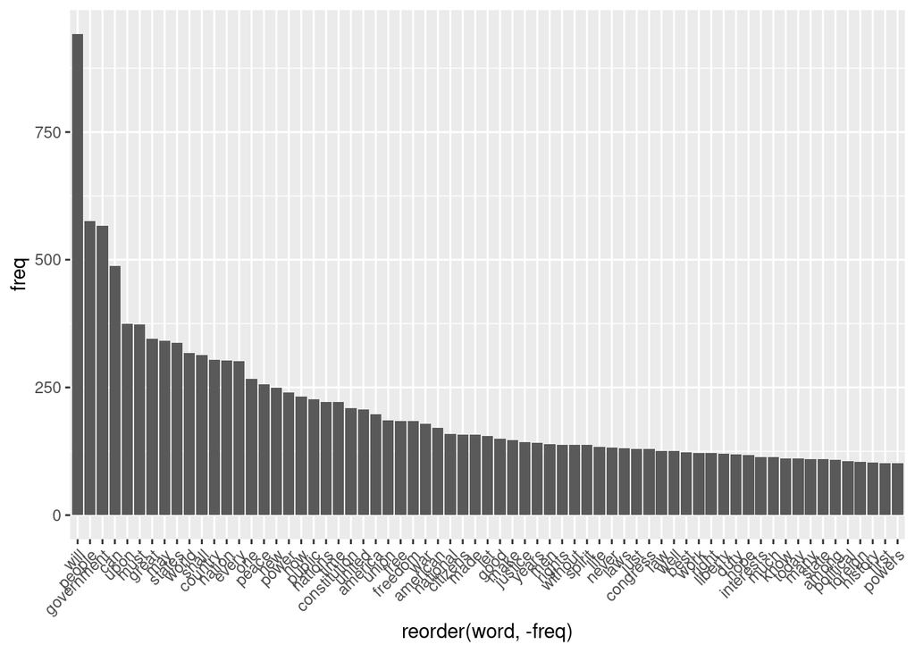

```r
p <- ggplot(subset(wf, freq>100), aes(x = reorder(word, -freq), y = freq)) +
  geom_bar(stat = "identity") +
  theme(axis.text.x=element_text(angle=45, hjust=1))

p
```